# PopGen1

Jelard Aquino

2/2/2019

## Population Genetics Exercise 1

A metapopulation of Swalllowtail butterflies inhabited some islands in Southeast Asia. The metapopulation had 25 subpopulations and each subpopulation consists of 990 diploid individuals genotyped at a single SNP with three possible genotypes: CC, CG, and GG.

### Generating the data

I have generated a random sample of 25 subpopulations with 990 diploid individuals having genotypes of CC, CG, or GG.

```r
pops_before <- replicate(25, sample(c("CC", "CG", "GG"), 990, replace=TRUE), simplify=FALSE)

names(pops_before)<-paste("pop", 1:25, sep="")
```

### Allele Frequency

Next, I calculated the frequency of C in each of the subpopulation.

```r
freq_C_before <- lapply(pops_before, function(x) ((sum(x == "CC")*2) + sum(x == "CG"))/1980)

freq_C_before
```

```
## $pop1
## [1] 0.4848485
##
## $pop2
## [1] 0.480303
##
## $pop3
## [1] 0.5040404
##
## $pop4
## [1] 0.5126263
##
## $pop5
## [1] 0.5015152
##
## $pop6
## [1] 0.5040404
##
## $pop7
## [1] 0.4944444
##
## $pop8
## [1] 0.5146465
##
## $pop9
## [1] 0.4747475
##
## $pop10
## [1] 0.4873737
##
## $pop11
## [1] 0.5040404
##
## $pop12
## [1] 0.5060606
##
## $pop13
## [1] 0.4924242
##
## $pop14
```

[output cut: 19 more lines]

```
##
## $pop21
## [1] 0.5070707
##
## $pop22
## [1] 0.5035354
##
## $pop23
## [1] 0.5005051
##
## $pop24
## [1] 0.5055556
##
## $pop25
## [1] 0.5161616
```

Then, I calculated the frequency of G in each of the subpopulation.

```r
freq_G_before <- lapply(pops_before, function(x) ((sum(x == "GG")*2) + sum(x == "CG"))/1980)

freq_G_before
```

```
## $pop1
## [1] 0.5151515
##
## $pop2
## [1] 0.519697
##
## $pop3
## [1] 0.4959596
##
## $pop4
## [1] 0.4873737
##
## $pop5
## [1] 0.4984848
##
## $pop6
## [1] 0.4959596
##
## $pop7
## [1] 0.5055556
##
## $pop8
## [1] 0.4853535
##
## $pop9
## [1] 0.5252525
##
## $pop10
## [1] 0.5126263
##
## $pop11
## [1] 0.4959596
##
## $pop12
## [1] 0.4939394
##
## $pop13
## [1] 0.5075758
##
## $pop14
```

[output cut: 19 more lines]

```
##
## $pop21
## [1] 0.4929293
##
## $pop22
## [1] 0.4964646
##
## $pop23
## [1] 0.4994949
##
## $pop24
## [1] 0.4944444
##
## $pop25
## [1] 0.4838384
```

The average frequency of C from each subpopulation can be used to obtain the frequency of C for the metapopulation.

```r
mean(unlist(freq_C_before))
```

```
## [1] 0.5013939
```

The above statement is also true to obtain the frequency of G for the metapopulation.

```r
mean(unlist(freq_G_before))
```

```
## [1] 0.4986061
```

Due to a fire-caused disturbance, each population loses 25% of its individuals.

```r
pops_after <- lapply(pops_before, function(x) sample(x, 742, replace=FALSE))
```

Note: You want to use without replacement because you want to randomly take 742 individuals from the 990 individuals for each population. In the earlier code, we used with replacement because we were generating data using the three genotypes which was reused to make 990 individuals.

The new frequency of C from each subpopulation is:

```r
freq_C_after <- lapply(pops_after, function(x) ((sum(x == "CC")*2) + sum(x == "CG"))/1484)
```

The new frequency of G from each subpopulation is:

```r
freq_G_after <- lapply(pops_after, function(x) ((sum(x == "GG")*2) + sum(x == "CG"))/1484)
```

The frequency of C and G of the metapopulation is:

```r
mean(unlist(freq_C_after))
```

```
## [1] 0.5009164
```

```r
mean(unlist(freq_G_after))
```

```
## [1] 0.4990836
```

respectively.

Below is a plot showing the change in frequency of C across the 25 subpopulations:

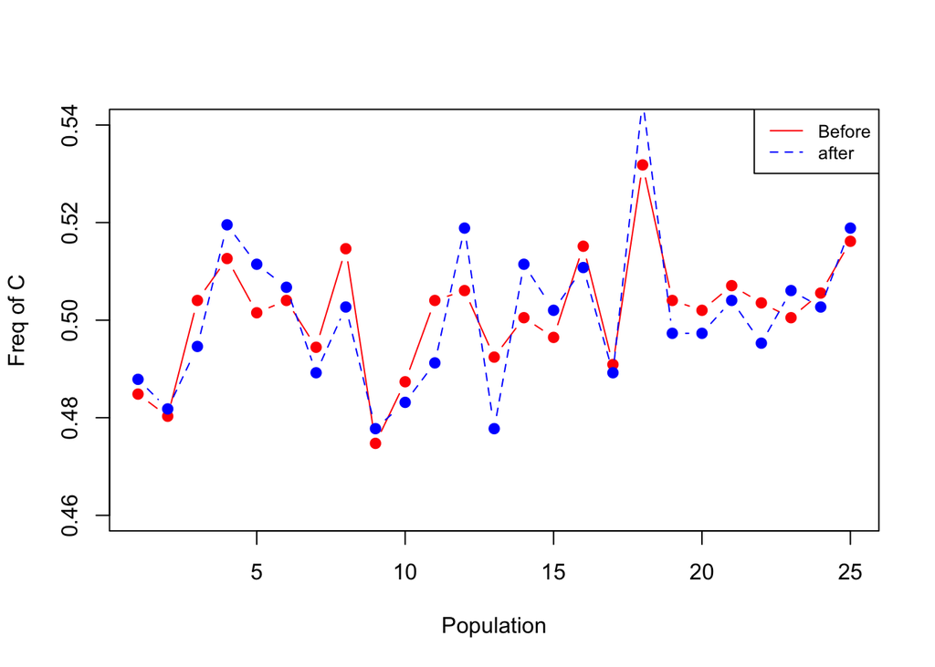

From this plot, the frequency of C before and after the fire are very similar. This means that the fire had very little effect on the frequency of C. A Chi-Square Test will test the significance of this effect.